# SESAM Soil enzyme steady allocoation model

The SEAM model explicitely tracks enzyme levels. In order to use the model at plot scale or in COMISSION, derive a simpler version, where enzyme levels are assumed to be in fast steady state with production and turnover.

Here, we explore instead of tracking enzymes, we track microbial community either attacking R or L litter, by modelling $\alpha$ as a state variable. The computation of $\alpha_{Target}$ is based on current revenue, and hence current $\alpha$.

Microbial community can only change as fast as microbial turnover.
$$\frac{d\alpha}{dt} = \tau (\alpha_{Target} - \alpha)$$

## Model versions

- SEAM2: enzyme explicit (soil enzyme allocation model)
- SESAM3a: enzyme in steady state but explicitely tracking $\alpha$
  - SESAM3s: deprecated predecessor with still using parameters km and kN
- SESAM3B: also microbial biomass in steady state

## Comparison using the FACE scenario

### Setup parameters and drivers

Mass units are $gC/m^2$ or $gN/m^2$. Time unit is $yr$.

```r
require(sesam)
```

```r
parmsModel <- list(
  cnB = 11
  ,cnE = 3.1     # Sterner02: Protein (Fig. 2.2.), high N investment (low P) need
    # to have low C/N for CO2 increase scenario
  ,kN = 60       ##<< /yr enzyme turnover 60 times a year, each 6 days -> fast
    # priming pulses
  ,km = 0.05     ##<< enzyme half-saturation constant, in magnitude of enzymes,
    # determined by kN
  ,kNB = 0.8     ##<< amount of recycling enzyme turnover by biomass (
    # added to assimilable, i.e. uptake instead of R)
  #,kR = 1/(10)        ##<< 1/(x years) # to demonstrate changes on short time scale
  ,kR = 1/(20)        ##<< 1/(x years) # to demonstrate changes on short time scale
  ,kL = 5           ##<< 1/(x years)   # formerly 1 year
  ,aE = 0.001*365   ##<< C biomass allocated to enzymes 1/day /microbial biomass
  ,m = 0.005*365    ##<< maintenance respiration rate   1/day /microbial biomass,
  ## Bogedom Fig. 1
  ,tau = 1/60*365  ##<< biomass turnover rate (12 days)
  ,eps = 0.5      ##<< carbon use efficiency for growth respiration
  #,epsTvr = 0.3   ##<< carbon use efficiency of microbial tvr (part by predators
  ,epsTvr = 0.45   ##<< carbon use efficiency of microbial tvr (part by predators
  ## which respire and corresponding amount of N must be mineralized)
  #,iB = 0.38 * 10.57 #0.0110068*365   ##<< potential immobilization flux rate
  ,iB = 0.4 ##<< potential immobilization flux rate
  ## (immoPot = iB I)
  ,l = 0.96       #0.00262647*365     ##<< leaching rate of mineralN l I
  ,nu = 0.9     # microbial N use efficiency accounting for apparent
  ## minceralization of N during uptake in heterogeneous soils
  , isEnzymeMassFlux = TRUE  ##<< compute enzyme mass fluxes
  ,kIPlant = 10.57 #0.0289652*365     ##<< plant uptake rate first order of I
)

parmsModel <- within(parmsModel, {
  kmN <- km*kN     # Sesam2 only uses a lumped parameter instead of km and kN
  kmR <- kmL <- km  # seam2 can accept parameters differing by substrate
  cnER <- cnEL <- cnE
  kNR <- kNL <- kN
  #isFixedI <- TRUE  # in this demonstration keep inorganic pool fixed
})
```

For simplicity model drivers currently are prescibed as constant parameters.

```r
drivers <- list(
  iR = 0          ##<< input of residue litter
  ,iL = 400         # g/m2 input per year (half NPP)
  ,cnIR = 7       ##<< C/N ratio of the residue litter input
  ,cnIL = 30      ##<< C/N ratio of the labile litter input:
  ## N poor substrate, here no inorganic N supply,
  ,plantNUp = 0   ##<< pland uptake of organic N
  ## currently as absolute flux
  ,iI = 0         ##<< input of mineral N
)
parms0 <- within( c(parmsModel, drivers), {
  kIPlant <- 0
  plantNUpAbs <- iL/cnIL
})
parms0Noenz <- within(parms0, isEnzymeMassFlux <- FALSE)
```

The initial pools must be specified. The Steady models do not have the enzyme pools as state variables.

```r
x0 <- x0Explicit <- c( #aE = 0.001*365
        B = 17                     ##<< microbial biomass
        ,ER  = 2*parms0$km                  ##<< total enzyme pool
        ,EL  = 4*parms0$km                   ##<< total enzyme pool
        ,R = 1100                ##<< N rich substrate
        ,RN = 1100/parms0$cnIR   ##<< N rich substrate N pool
        ,L = 100                 ##<< N poor substrate
        ,LN = 100/parms0$cnIL    ##<< N poor substrate N pool
        ,I =  0.04                ##<< inorganic pool gN/m2
        , alpha = 0.5            ##<< microbial community partitioning [0,1]
)
x0Steady <- x0Explicit[c("B","R","RN","L","LN","I")]
x0SteadyA <- c(x0Steady,alpha = 0.5)
x0B <- x0SteadyA[setdiff(names(x0SteadyA),"B")]
```

We store the information that differs between scenarios in a tibble.

```r
scenarios <- tibble::tibble(
  scenario = c("Explicit","Sesam3a","NeglectEnzFlux","Sesam3B")
  ,mod = c(derivSeam3a, derivSesam3a, derivSesam3a, derivSesam3B)
  ,x0  = list(x0Explicit, x0SteadyA, x0SteadyA, x0B)
  ,parms = list(parms0, parms0, parms0Noenz, parms0)
)
tmp <- structure(myColors[1:nrow(scenarios)], names = scenarios$scenario)
colScale <- scale_colour_manual(name = "Model variant",values = tmp )
```

Next the simulation runs are performed.

```r
runFaceSimulation <- function(
  scen, t1S =20, t2I = 50, t3S = 50, parms = parms0
){
  # spinup to steady state
  times <- seq(0,500, length.out = 2)
  #setwd("../..");loadPkg()
  . <- scen
  res <- res1 <- as.data.frame(lsoda( .$x0, times, .$mod, parms = .$parms))
  xE <- unlist(tail(res,1))
  #xE["I"] <- 0.04  # decrease I pool # does not help filled up by mircobial tvr
  #
  # t1S years of steady state recorded
  res <- res1S <- as.data.frame(lsoda(
    xE[1:length(.$x0) + 1], 1:t1S, .$mod, parms = .$parms))
  #
  # t2I years of increased input
  fInputInc = 1.2
  parmsC2 <- within(.$parms, {# more C in litter, but not more N
    iL <- iL*fInputInc
    cnIL <- cnIL*fInputInc
  })
  times <- seq(0,t2I, length.out = t2I*6 + 1)# record bymonthly
  res <- res2I <- as.data.frame(lsoda(
    xE[1:length(.$x0) + 1], times, .$mod, parms = parmsC2))
  res2I$time <- res2I$time + t1S
  xE2 <- unlist(tail(res2I,1))
  #
  # t3S years of initial input
  times <- seq(0,t3S, length.out = t3S*6 + 1) # record bymonthly
  res <- res3S <- as.data.frame(lsoda(
    xE2[1:length(.$x0) + 1], times, .$mod, parms = .$parms))
  res3S$time <- res3S$time + t1S + t2I
  xE3 <- tail(res3S,1)
  resc <- rbind( res1S, res2I[-1,], res3S[-1,])
  resc$scen <- scen$scenario
  resc
}
.tmp.f <- function(){
  scen <- unlist(filter(scenarios, scenario == "Explicit"), recursive = FALSE)
  scen <- unlist(filter(scenarios, scenario == "Sesam3a"), recursive = FALSE)
  scen <- unlist(filter(scenarios, scenario == "Sesam3B"), recursive = FALSE)
  resScen <- runFaceSimulation( scen )
}
resScen <- scenarios %>%
  #filter(scenario == "Sesam3a") %>%
  rowwise() %>% do( runFaceSimulation(.) )
```

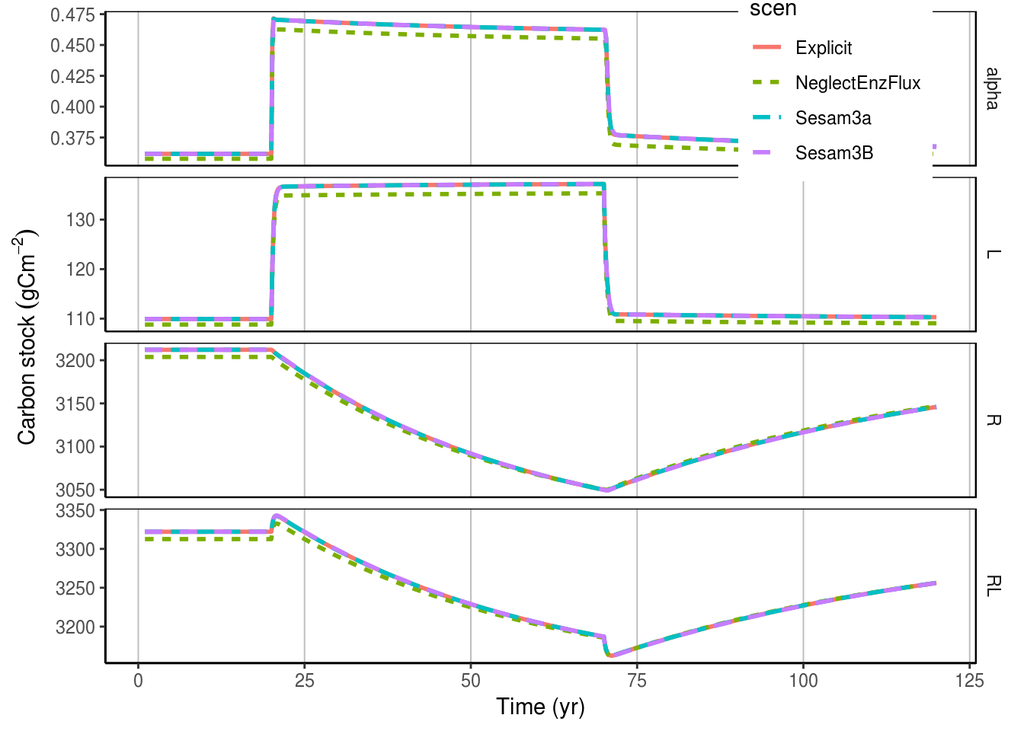

```r
vars <- c("L","R","alpha","RL")
#vars <- c("L","R","alpha","B","RL","cnRL")
#vars <- c("alpha","B", "cnL", "PhiB","PhiTotal","immoPot", "CsynBC","CsynBN")
dsp <- resScen %>% mutate_(RL = ~(R+L), cnRL = ~((R+L)/(RN+LN))) %>%
  #select_(~time, ~scen, ~L, ~R, ~RL) %>% gather_("Pool","value", c("L","R","RL"))
  select(one_of(c("time","scen",vars))) %>% gather_("Pool","value", vars)
p2f <- ggplot( dsp, aes(x = time, y = value, col = scen, linetype = scen)) + geom_line(size = 1) +
  facet_grid(Pool ~ .,scales = "free") +
  xlab("Time (yr)") + ylab(expression(Carbon~stock~(gCm^{-2}))) + #labs(linetype = "Substrate pool") +
  themeDefault +
  #scale_colour_discrete(drop = TRUE,limits = levels(dsp$Allocation)) +
  theme(legend.position = c(0.95,1.04), legend.justification = c(1,1)) +
  theme(panel.border = element_rect(colour = "black", fill = NA)) +
  theme(strip.background = element_blank()) +
  theme(panel.grid.major.x = element_line(colour = "grey75")) +
  c()
#print(p2f + colScale)
print(p2f)
```

Model Sesam3a matches the dynamics of the explicit SEAM model at this time scale. When neglecting enzyme mass fluxes, the dynamcis is similar, but the steady state , expecially for R, is slightly lower.

The model with steady state microbial biomass, Sesam3B, captures the same dynamics.